# Modul 1: Pengenalan R dan RStudio

Instalasi, Antarmuka, dan Operasi Dasar

Offline di Departemen Matematika

Author

Tim Asisten Lab Matematika UI

Published

September 15, 2026

Kembali ke arsip PSD

## Tujuan Pembelajaran

Setelah menyelesaikan modul ini, mahasiswa diharapkan mampu:

- **1. Memahami Konsep Dasar Lingkungan Kerja Sains Data**
  - Menjelaskan peran dan kegunaan dasar Bahasa R dalam analisis data.
  - Membedakan fungsi antara R sebagai *engine* komputasi dan RStudio sebagai *Integrated Development Environment* (IDE).
- **2. Melakukan Persiapan dan Instalasi Perangkat Lunak**
  - Melakukan aktivasi lisensi Microsoft 365 dan menginstal Microsoft Excel menggunakan akun mahasiswa UI.
  - Mengunduh dan menginstal Bahasa R dengan benar sesuai dengan sistem operasi yang digunakan (Windows/macOS).
  - Mengunduh dan menginstal RStudio Desktop sebagai antarmuka utama untuk pemrograman R.
- **3. Mengaplikasikan Dasar-Dasar Pemrograman R**
  - Menggunakan konsol R sebagai kalkulator untuk melakukan operasi aritmatika dasar.
  - Mendefinisikan, memanggil, dan melakukan operasi antar variabel menggunakan operator `<-` dan `=`.
  - Mengelola variabel di *environment* RStudio, termasuk melihat daftar variabel yang aktif dan menghapusnya.

## Pengenalan R

R adalah bahasa pemrograman dan lingkungan perangkat lunak gratis untuk komputasi statistik dan grafik. R banyak digunakan oleh para statistisi dan penambang data untuk mengembangkan perangkat lunak statistik dan analisis data.

**Apa Bedanya R dan RStudio?**

Pikirkan R sebagai **mesin mobil**—ini adalah inti yang melakukan semua pekerjaan komputasi. Sementara itu, RStudio adalah **dasbor mobil** (setir, pedal, spion, GPS)—ini adalah *Integrated Development Environment* (IDE) yang memberikan antarmuka grafis yang nyaman untuk bekerja dengan R. Kita menulis dan menjalankan kode di RStudio, tetapi R-lah yang mengeksekusinya di belakang layar.

### Operasi Dasar di R

Kita bisa menggunakan R sebagai kalkulator canggih. Berikut adalah contoh beberapa operasi dasar.

**Aritmatika**

Contoh kode untuk operasi aritmatika dasar.

```r
# Penjumlahan
5 + 3

# Pengurangan
10 - 4

# Perkalian
7 * 6

# Pembagian
40 / 8

# Pangkat
2^5
```

**Logika**

Operasi logika menghasilkan nilai `TRUE` atau `FALSE`.

```r
# Apakah 5 lebih besar dari 3?
5 > 3

# Apakah 10 sama dengan 10? (gunakan ==)
10 == 10

# Apakah 7 tidak sama dengan 8? (gunakan !=)
7 != 8
```

## Instalasi Excel, R, dan RStudio

Selama praktikum PSD (Pengantar Sains Data), kita akan menggunakan *software* Microsoft Excel, serta bahasa pemrograman R melalui *software* RStudio. Berikut ini adalah petunjuk untuk menginstal *software* tersebut.

**Link Modul**

Untuk modul instalasi yang lebih spesifik pada masing-masing *operating system*, silakan lihat di link berikut:

[Modul Instalasi Excel, R, RStudio Windows](https://drive.google.com/file/d/1I69RV903anr4Bbr7AcWkKcu-hDoaZZZj/view?usp=sharing)

[Modul Instalasi Excel, R, RStudio MacOS](https://drive.google.com/file/d/1yjKVNj88rdQUcMvVAKETTeoKK-i1dCzG/view?usp=sharing)

### Aktivasi Microsoft Office dan Instalasi Excel

Microsoft Excel sebenarnya adalah *software* berbayar, sebagaimana produk Microsoft lainnya dalam serial Office 365. Untungnya, Universitas Indonesia menyediakan layanan Office 365 untuk tiap email UI, meliputi aplikasi berikut:

- Microsoft Word
- Microsoft Excel
- Microsoft PowerPoint
- Microsoft Outlook
- Microsoft OneDrive
- Microsoft Teams

Sehingga, tiap mahasiswa UI bisa melakukan aktivasi Office 365 agar bisa menggunakan *software* tersebut secara gratis. Tidak hanya untuk PSD, produk Microsoft akan cukup menunjang selama perkuliahan, terutama ketika ada tugas kuliah yang diketik, seperti menyiapkan makalah dan presentasi, apalagi tugas kelompok (bisa bekerja sama, memanfaatkan OneDrive).

Setelah aktivasi, barulah produk yang diinginkan bisa di-*download* lalu diinstal, agar bisa digunakan. Berikut ini kami jelaskan langkah-langkahnya.

Informasi lebih lanjut juga bisa dilihat di tautan resmi berikut: https://dsti.ui.ac.id/mulai-dengan-office-365/

[figure not shown]

### Aktivasi Microsoft Office dengan email UI dan *login*

1. Buka tautan https://sso.ui.ac.id/office365

Tampilannya seperti berikut:

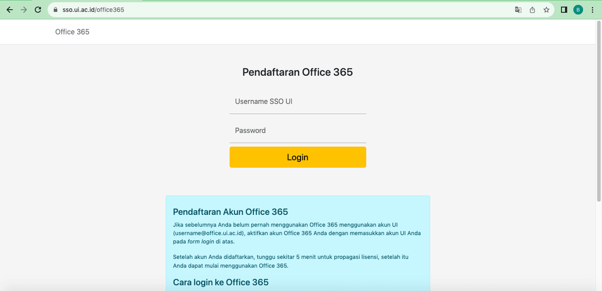

2. Masukkan *username* SSO UI serta *password* milik pribadi, lalu tekan “Login”. Akun SSO yang dimaksud adalah akun yang sama yang biasa digunakan untuk *login* ke SIAK NG, ke EMAS2, dan sebagainya, yaitu tanpa akhiran `@ui.ac.id` maupun akhiran `@office.ui.ac.id`
3. Tunggu sekitar 5 (lima) menit, lalu buka *tautan* https://office365.ui.ac.id

Apabila perlu *login*, seperti pada tampilan berikut, silakan *login* dengan akun SSO yang sama seperti langkah sebelumnya.

[figure not shown]

4. Untuk halaman ini, bebas memilih No atau Yes. Sebaiknya pilih Yes agar tidak terlalu sering *login* ke depannya.

[figure not shown]

*Login* berhasil.

### Instalasi dan Penggunaan Excel

1. Kunjungi tautan https://office365.ui.ac.id dan lakukan *login* kalau belum.
2. Pilih “Install and more”, lalu tekan “Install Microsoft 365 apps”, seperti berikut.

[figure not shown]

3. Akan muncul tampilan seperti berikut. Tekan tombol “Install Office” untuk men-*download* suatu *installer* berukuran sekitar 3 GB.

[figure not shown]

4. Ikuti petunjuk instalasi yang diberikan. Pastikan Excel terpilih sebagai salah satu aplikasi yang ingin diinstal.
5. Setelah instalasi selesai, bukalah Excel. Akan muncul tampilan seperti berikut. Tekan tombol “Sign in”.

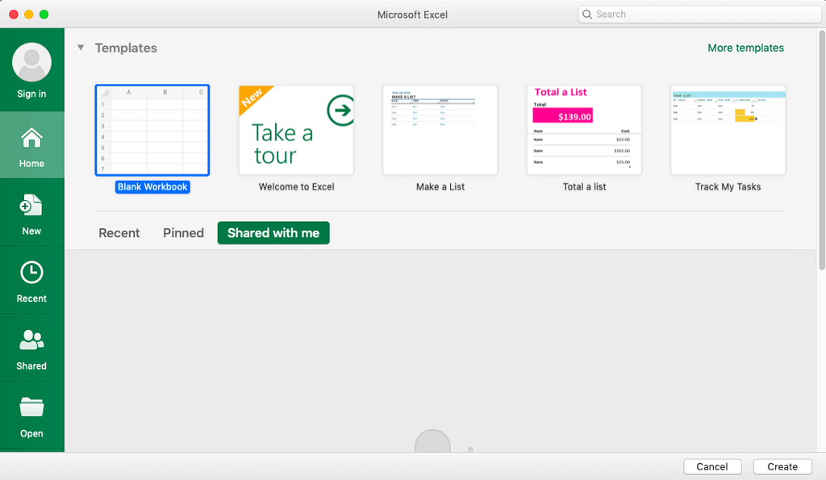

6. Setelah itu, muncul tampilan *login* seperti berikut. Masukkan email UI, tetapi dengan akhiran `@office.ui.ac.id`, lalu tekan “Next”

[figure not shown]

7. Akan muncul tampilan *login* SSO, seperti berikut. Gunakan *username* SSO UI dan *password*, lalu tekan “Login”

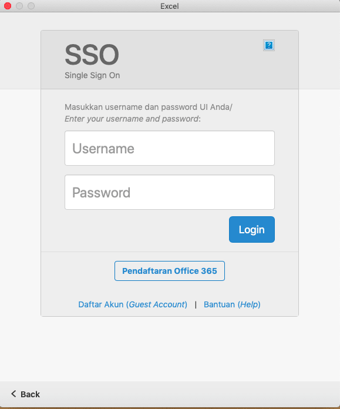

Selamat, *login* berhasil. Excel sudah bisa digunakan, bahkan *file* yang disimpan di OneDrive juga bisa diakses.

### *Download* dan Instalasi R

1. Kunjungi tautan https://cran.r-project.org/ (atau coba *searching* “CRAN R” dan pencet *website* pertama yang muncul). Isinya akan seperti berikut:

[figure not shown]

2. Pilih tautan yang sesuai dengan *operating system* (sistem operasi) dari *laptop* atau perangkat yang sedang digunakan.

- Apabila perangkatmu menggukanan *operating system* Windows, tekan “Download R for Windows”.

- Apabila perangkatmu menggukanan *operating system* macOS, tekan “Download R for macOS”.

Langkah ketiga dan seterusnya tergantung *operating system*, tetapi harusnya cukup mirip.

#### Untuk Windows

3. Setelah itu, muncul laman seperti berikut. Tekan “base”.

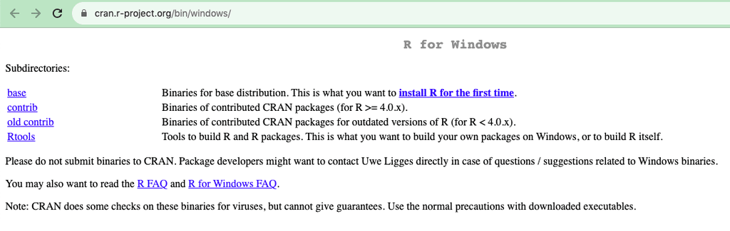

4. Di laman berikut, akan muncul versi R terbaru yang tersedia. Tekan *tautan* “Download R-… for Windows” tersebut untuk memulai *download*.

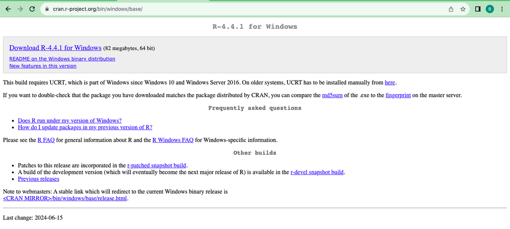

(Lakukan instalasi dengan membuka *file* tersebut dan menyetujui segalanya.)

#### Untuk macOS

3. Setelah itu, muncul laman seperti berikut. *Scroll* ke bawah sedikit, tersedia beberapa pilihan versi R yang bisa di-*download*, tergantung versi macOS yang sedang digunakan.

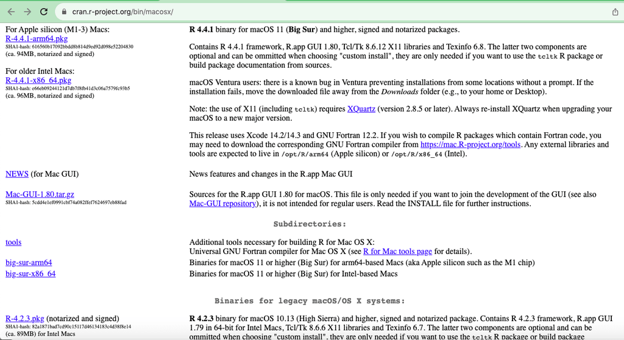

Pada gambar di atas, versi R terbaru yang tersedia adalah R-4.4.1 untuk versi minimum macOS 11. Tersedia dua tautan untuk men-*download* versi R tersebut, yaitu

- `R-4.4.1-arm64.pkg` untuk Mac M1, M2 dan seterusnya, yaitu menggunakan prosesor Apple Silicon - `R-4.4.1-x86_64.pkg` untuk Mac yang dirilis sebelum M1, yaitu menggunakan prosesor Intel

Apabila versi minimum macOS terpenuhi, silakan pilih tautan *download* yang lebih cocok di antara kedua pilihan tersebut.

Namun, apabila versi macOS yang sedang digunakan tidak memenuhi kriteria di atas, *scroll* lagi ke bawah untuk melihat pilihan versi R yang terpenuhi versi minimumnya untuk macOS.

Contohnya, di bagian bawah pada gambar di atas, terlihat pilihan *download* `R-4.2.3.pkg` yaitu R versi 4.2.3, untuk versi minimum macOS 10.13.

4. Setelah memilih dan menekan tautan tersebut, R akan mulai ter-*download*. Setelah selesai, bukalah *file* `.pkg` tersebut. Akan muncul tampilan seperti berikut. Tekan “Continue”.

[figure not shown]

5. Kemudian, ada sedikit penjelasan tentang versi yang sedang diinstal, seperti berikut. Tekan “Continue”.

[figure not shown]

6. Ada sedikit himbauan tentang lisensi yang digunakan oleh R, yaitu GNU GPL, seperti berikut. Intinya, *software* ini bebas digunakan dan disebarkan secara gratis. Tekan “Continue”.

[figure not shown]

7. Muncul semacam permintaan konfirmasi terkait persetujuan lisensi, seperti berikut. Setujuilah dengan menekan “Agree”.

[figure not shown]

8. Ada konfirmasi tentang tempat men-*download* dan *storage* yang dibutuhkan. Tekan “Continue”.

[figure not shown]

[figure not shown]

10. Bisa saja muncul konfirmasi sekali lagi, seperti berikut, kali ini membutuhkan *password* untuk *laptop* yang digunakan. Masukkan, lalu tekan “Install Software”. Kalau *laptop* yang digunakan sebenarnya tidak terpasang *password*, langsung tekan “Install Software” tanpa mengetik apapun.

[figure not shown]

11. Instalasi akan berjalan selama sekitar beberapa menit, dengan tampilan seperti berikut. Harap ditunggu, boleh sambil melakukan hal lain.

[figure not shown]

12. Setelah instalasi selesai, tampilan akan seperti berikut. Tekan “Close”.

[figure not shown]

13. Sebelum benar-benar menutupnya, ada konfirmasi apakah *installer* yang telah di-*download* sebelumnya itu ingin tetap disimpan atau dihapus. Pilihan ini terserah, tetapi sangat dipersilakan untuk menghapus, karena R akan tetap bisa digunakan walaupun *installer*-nya sudah dihapus.

[figure not shown]

14. Silakan buka *folder* “Applications”, kemudian *scroll* ke bawah hingga menemukan R, untuk membuka R.

[figure not shown]

15. Tampilan R setelah dibuka akan seperti berikut. Perintah-perintah bahasa R sudah bisa diketik dan dijalankan.

[figure not shown]

Daripada langsung menggunakan R, sebaiknya gunakan RStudio (yang perlu diinstal secara terpisah) untuk memperoleh tampilan yang lebih nyaman digunakan.

### *Download* dan Instalasi RStudio

1. Kunjungi tautan https://posit.co/download/rstudio-desktop/ (atau coba *searching* “RStudio Desktop” dan pencet *website* pertama yang muncul). Isinya akan seperti berikut, tergantung *operating system* yang sedang digunakan:

[figure not shown]

Tekan tombol “Download” di sebelah kanan, apabila memenuhi kriteria versi *operating system* yang digunakan. Apabila tidak memenuhi, kunjungi https://dailies.rstudio.com/rstudio/ dan carilah versi RStudio yang kompatibel dengan versi *operating system* yang digunakan. Tampilan *website* tersebut seperti berikut.

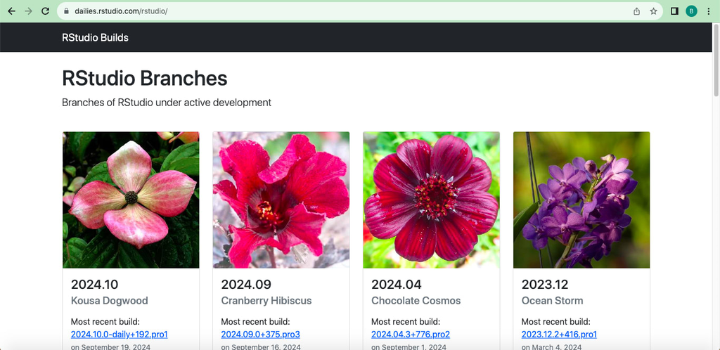

Langkah kedua dan seterusnya tergantung *operating system*.